# Wine Dataset

Anant Sharma

10/30/2019

# PART I(White Wine)

## Reading the DATA

```r
  white.url <- "https://archive.ics.uci.edu/ml/machine-learning-databases/wine-quality/winequality-white.csv"
  data.white<-read.csv(white.url,header=TRUE,sep=';')
  head(data.white)
```

```
##   fixed.acidity volatile.acidity citric.acid residual.sugar chlorides
## 1           7.0             0.27        0.36           20.7     0.045
## 2           6.3             0.30        0.34            1.6     0.049
## 3           8.1             0.28        0.40            6.9     0.050
## 4           7.2             0.23        0.32            8.5     0.058
## 5           7.2             0.23        0.32            8.5     0.058
## 6           8.1             0.28        0.40            6.9     0.050
##   free.sulfur.dioxide total.sulfur.dioxide density   pH sulphates alcohol
## 1                  45                  170  1.0010 3.00      0.45     8.8
## 2                  14                  132  0.9940 3.30      0.49     9.5
## 3                  30                   97  0.9951 3.26      0.44    10.1
## 4                  47                  186  0.9956 3.19      0.40     9.9
## 5                  47                  186  0.9956 3.19      0.40     9.9
## 6                  30                   97  0.9951 3.26      0.44    10.1
##   quality
## 1       6
## 2       6
## 3       6
## 4       6
## 5       6
## 6       6
```

## Exploring the DATA

```r
  dim(data.white)
```

```
## [1] 4898   12
```

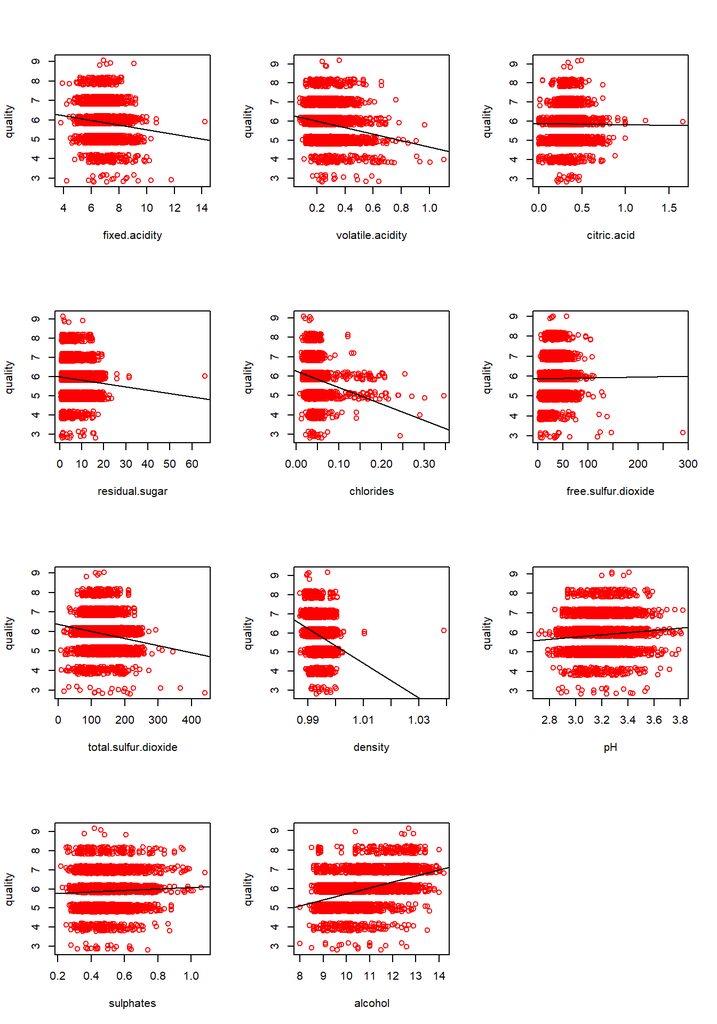

```r
  par(mfrow=c(4,3))
  for(i in 1:11)
  {
    plot(data.white[,i],jitter(data.white[,"quality"]),col="red",xlab=names(data.white)[i],ylab="quality")
    abline(lm(data.white[,"quality"]~data.white[,i]))
  }
```

```r
  data.white<-data.white[-which.max(data.white$residual.sugar),]
```

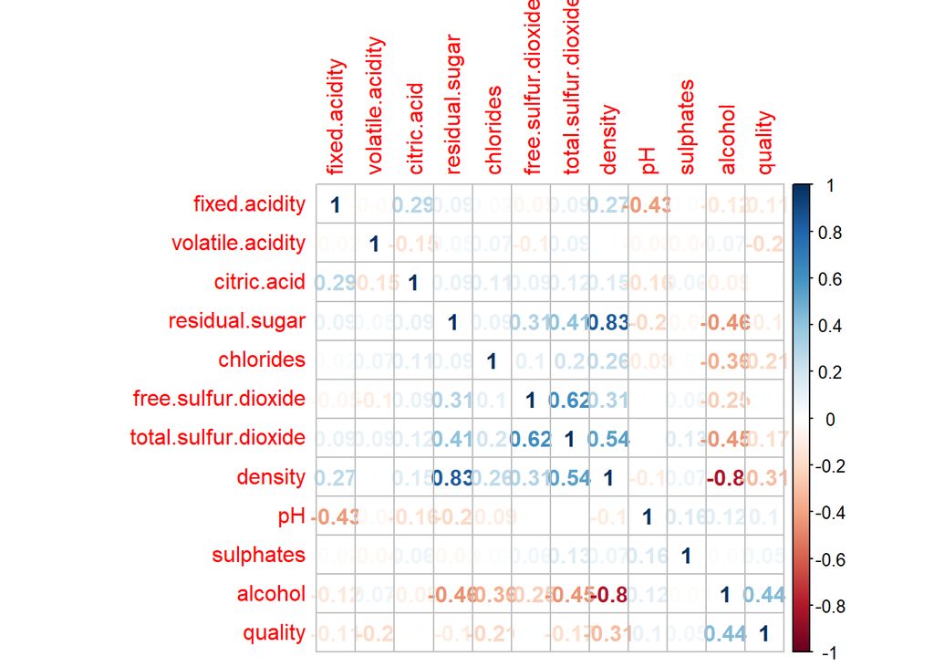

```r
  library(corrplot)
  corr.white<-cor(data.white)
  corrplot(corr.white,method="number")
```

## Model building

First we would convert the quality variable to factor and then we split data and then build model over it.

```r
  data.white$quality<-factor(data.white$quality)
  library(caret)
  intrain<-createDataPartition(y=data.white$quality,p=0.7,list=FALSE)
  train.white<-data.white[intrain,]
  test.white<-data.white[-intrain,]
```

I would test three models knn, random forest and SVM(support vector machine).

## 1) KNN

```r
  tr.ctrl<-trainControl(method="repeatedcv",number=2,repeats=2)
  knn.grid<-expand.grid(distance=c(1,2),kmax=c(3,5,7,9,11),kernel=c("rectangular","gaussian","cos"))
  knn.fit<-train(quality~.,data=train.white,trcontrol=tr.ctrl,tuneGrid=knn.grid,preProcess=c("center","scale"),method="kknn")
  confusionMatrix(predict(knn.fit,test.white),test.white$quality)
```

```
## Confusion Matrix and Statistics
##
##           Reference
## Prediction   3   4   5   6   7   8   9
##          3   0   0   1   0   0   0   0
##          4   2  12  15  10   0   0   0
##          5   1  20 290 121  13   3   0
##          6   3  13 110 445  76  14   0
##          7   0   2  20  69 160  11   0
##          8   0   1   1  14  15  24   1
##          9   0   0   0   0   0   0   0
##
## Overall Statistics
##
##                Accuracy : 0.6346
##                  95% CI : (0.6094, 0.6593)
##     No Information Rate : 0.4492
##     P-Value [Acc > NIR] : < 2.2e-16
##
##                   Kappa : 0.4565
##
##  Mcnemar's Test P-Value : NA
##
## Statistics by Class:
##
##                       Class: 3 Class: 4 Class: 5 Class: 6 Class: 7
## Sensitivity          0.0000000  0.25000   0.6636   0.6753   0.6061
## Specificity          0.9993155  0.98097   0.8466   0.7327   0.9152
## Pos Pred Value       0.0000000  0.30769   0.6473   0.6732   0.6107
## Neg Pred Value       0.9959072  0.97479   0.8557   0.7345   0.9137
## Prevalence           0.0040900  0.03272   0.2979   0.4492   0.1800
## Detection Rate       0.0000000  0.00818   0.1977   0.3033   0.1091
## Detection Prevalence 0.0006817  0.02658   0.3054   0.4506   0.1786
## Balanced Accuracy    0.4996578  0.61549   0.7551   0.7040   0.7606
##                      Class: 8  Class: 9
## Sensitivity           0.46154 0.0000000
## Specificity           0.97739 1.0000000
## Pos Pred Value        0.42857       NaN
## Neg Pred Value        0.98016 0.9993183
## Prevalence            0.03545 0.0006817
## Detection Rate        0.01636 0.0000000
## Detection Prevalence  0.03817 0.0000000
## Balanced Accuracy     0.71946 0.5000000
```

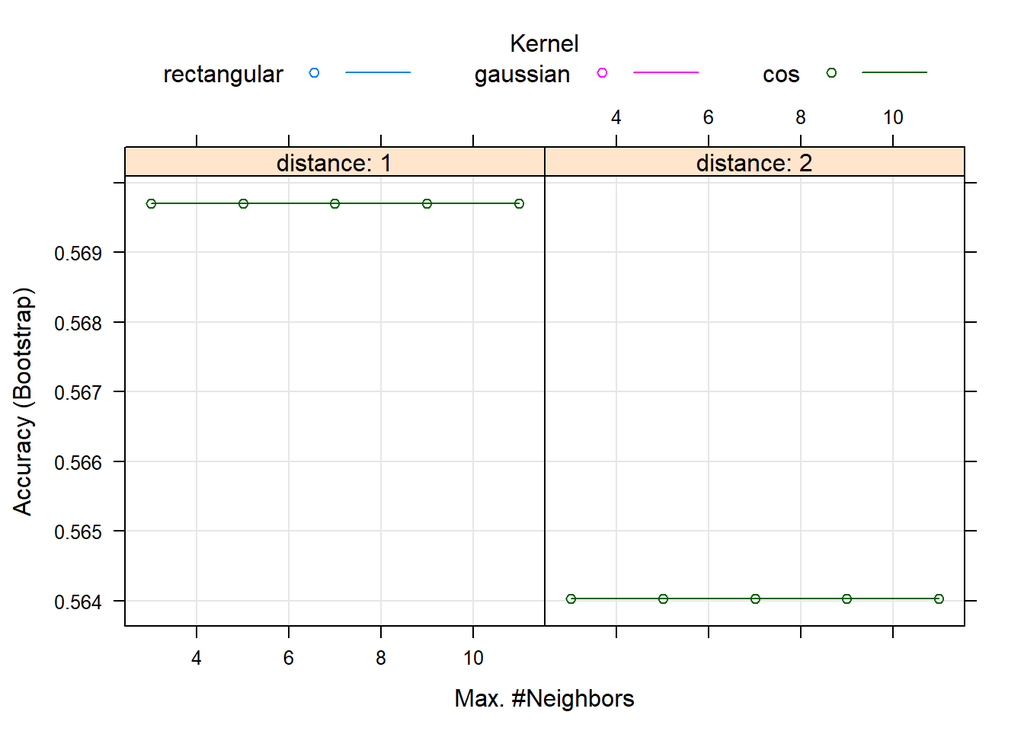

```r
  plot(knn.fit)
```

```r
  knn.fit$bestTune
```

```
##   kmax distance      kernel
## 1    3        1 rectangular
```

So we can see we get the best model for a rectangular kernel with distance 1 which represents manhattan distance and kmax=3.And also we get an accuracy of 63.46%.

## 2) Random forest

```r
  rf.grid<-expand.grid(mtry=1:11)
  rf.fit<-train(quality~.,data=train.white,method="rf",trcontrol=tr.ctrl,tuneGrid=rf.grid,preProcess=c("center","scale"))
  confusionMatrix(predict(rf.fit,test.white),test.white$quality)
```

```
## Confusion Matrix and Statistics
##
##           Reference
## Prediction   3   4   5   6   7   8   9
##          3   0   0   0   0   0   0   0
##          4   0   5   0   2   0   0   0
##          5   2  24 287  73   3   0   0
##          6   4  18 146 559 132  19   1
##          7   0   1   4  25 129   9   0
##          8   0   0   0   0   0  24   0
##          9   0   0   0   0   0   0   0
##
## Overall Statistics
##
##                Accuracy : 0.6844
##                  95% CI : (0.6599, 0.7081)
##     No Information Rate : 0.4492
##     P-Value [Acc > NIR] : < 2.2e-16
##
##                   Kappa : 0.4994
##
##  Mcnemar's Test P-Value : NA
##
## Statistics by Class:
##
##                      Class: 3 Class: 4 Class: 5 Class: 6 Class: 7 Class: 8
## Sensitivity           0.00000 0.104167   0.6568   0.8483  0.48864  0.46154
## Specificity           1.00000 0.998591   0.9010   0.6040  0.96758  1.00000
## Pos Pred Value            NaN 0.714286   0.7378   0.6359  0.76786  1.00000
## Neg Pred Value        0.99591 0.970548   0.8609   0.8299  0.89607  0.98060
## Prevalence            0.00409 0.032720   0.2979   0.4492  0.17996  0.03545
## Detection Rate        0.00000 0.003408   0.1956   0.3810  0.08793  0.01636
## Detection Prevalence  0.00000 0.004772   0.2652   0.5992  0.11452  0.01636
## Balanced Accuracy     0.50000 0.551379   0.7789   0.7261  0.72811  0.73077
##                       Class: 9
## Sensitivity          0.0000000
## Specificity          1.0000000
## Pos Pred Value             NaN
## Neg Pred Value       0.9993183
## Prevalence           0.0006817
## Detection Rate       0.0000000
## Detection Prevalence 0.0000000
## Balanced Accuracy    0.5000000
```

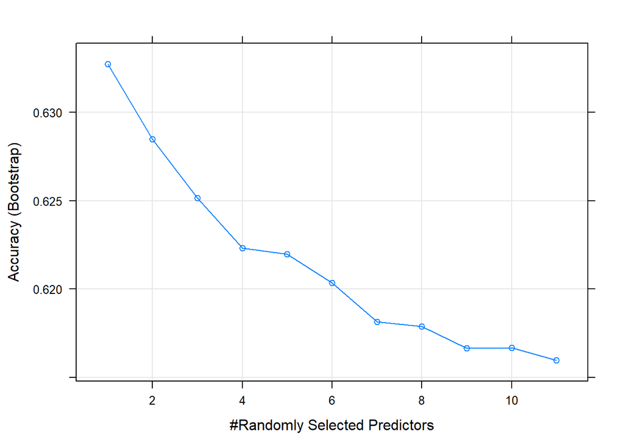

```r
  plot(rf.fit)
```

```r
  rf.fit$bestTune
```

```
##   mtry
## 1    1
```

Here we get an accuracy of 68.44% and also we can see that for mtry=1 we have maximum accuracy i.e for univariate tree.

## 3) Support vector machine(SVM)

```r
  svm.grid <- expand.grid(C = 2^(1:3), sigma = seq(0.25, 2, length = 8))
  svm.fit<-train(quality~.,data=train.white,method="svmRadial",trcontrol=tr.ctrl,tuneGrid=svm.grid,preProcess = c("center", "scale"))
  confusionMatrix(predict(svm.fit,test.white),test.white$quality)
```

```
## Confusion Matrix and Statistics
##
##           Reference
## Prediction   3   4   5   6   7   8   9
##          3   0   0   0   0   0   0   0
##          4   0   6   3   2   0   0   0
##          5   0   8 267  82   8   2   0
##          6   6  34 164 533 130  19   1
##          7   0   0   3  38 121  11   0
##          8   0   0   0   4   5  20   0
##          9   0   0   0   0   0   0   0
##
## Overall Statistics
##
##                Accuracy : 0.6455
##                  95% CI : (0.6204, 0.67)
##     No Information Rate : 0.4492
##     P-Value [Acc > NIR] : < 2.2e-16
##
##                   Kappa : 0.4389
##
##  Mcnemar's Test P-Value : NA
##
## Statistics by Class:
##
##                      Class: 3 Class: 4 Class: 5 Class: 6 Class: 7 Class: 8
## Sensitivity           0.00000 0.125000   0.6110   0.8088  0.45833  0.38462
## Specificity           1.00000 0.996476   0.9029   0.5619  0.95677  0.99364
## Pos Pred Value            NaN 0.545455   0.7275   0.6009  0.69942  0.68966
## Neg Pred Value        0.99591 0.971154   0.8455   0.7828  0.88949  0.97775
## Prevalence            0.00409 0.032720   0.2979   0.4492  0.17996  0.03545
## Detection Rate        0.00000 0.004090   0.1820   0.3633  0.08248  0.01363
## Detection Prevalence  0.00000 0.007498   0.2502   0.6046  0.11793  0.01977
## Balanced Accuracy     0.50000 0.560738   0.7569   0.6853  0.70755  0.68913
##                       Class: 9
## Sensitivity          0.0000000
## Specificity          1.0000000
## Pos Pred Value             NaN
## Neg Pred Value       0.9993183
## Prevalence           0.0006817
## Detection Rate       0.0000000
## Detection Prevalence 0.0000000
## Balanced Accuracy    0.5000000
```

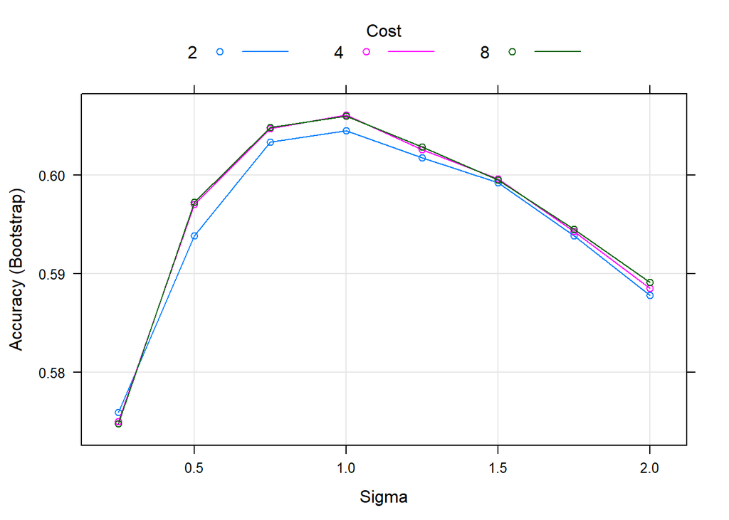

```r
  plot(svm.fit)
```

```r
  svm.fit$bestTune
```

```
##    sigma C
## 12     1 4
```

We get an accuracy of 64.55% with svm and also the best values for best accuracy are sigma=1 and C=4.

Since random forest gives the best accuracy and we choose it as our model.

# PART II(Red Wine)

## Reading the data

```r
  red.url<-"https://archive.ics.uci.edu/ml/machine-learning-databases/wine-quality/winequality-red.csv"
  data.red<-read.csv(red.url,header=TRUE,sep=';')
  head(data.red)
```

```
##   fixed.acidity volatile.acidity citric.acid residual.sugar chlorides
## 1           7.4             0.70        0.00            1.9     0.076
## 2           7.8             0.88        0.00            2.6     0.098
## 3           7.8             0.76        0.04            2.3     0.092
## 4          11.2             0.28        0.56            1.9     0.075
## 5           7.4             0.70        0.00            1.9     0.076
## 6           7.4             0.66        0.00            1.8     0.075
##   free.sulfur.dioxide total.sulfur.dioxide density   pH sulphates alcohol
## 1                  11                   34  0.9978 3.51      0.56     9.4
## 2                  25                   67  0.9968 3.20      0.68     9.8
## 3                  15                   54  0.9970 3.26      0.65     9.8
## 4                  17                   60  0.9980 3.16      0.58     9.8
## 5                  11                   34  0.9978 3.51      0.56     9.4
## 6                  13                   40  0.9978 3.51      0.56     9.4
##   quality
## 1       5
## 2       5
## 3       5
## 4       6
## 5       5
## 6       5
```

## Exploring the data

```r
  dim(data.red)
```

```
## [1] 1599   12
```

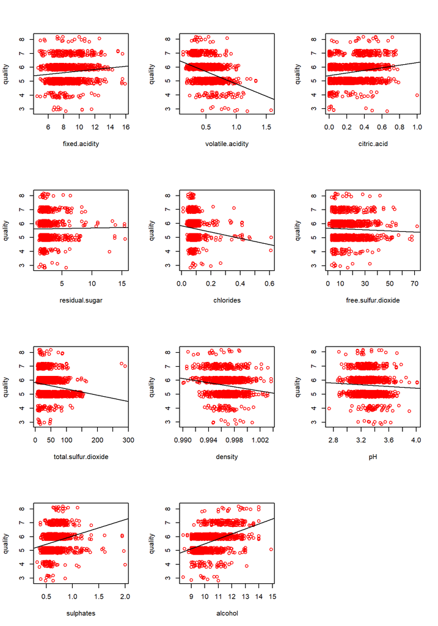

```r
  par(mfrow=c(4,3))
  for(i in 1:11)
  {
    plot(data.red[,i],jitter(data.red[,"quality"]),col="red",xlab=names(data.red)[i],ylab="quality")
    abline(lm(data.red[,"quality"]~data.red[,i]))
  }
```

From the above plots we conclude that free.sulfur.dioxide and residual.sugar do not have much relation with the wine quality.We plot a correlation plot to be sure below.

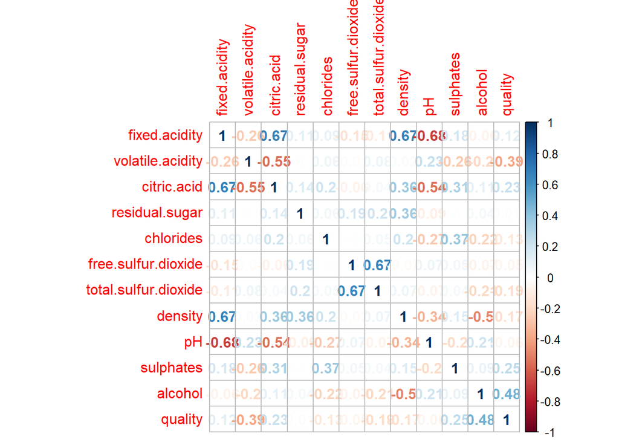

```r
  library(corrplot)
  corr.red<-cor(data.red)
  corrplot(corr.red,method="number")
```

Weak relationships between quality and residual.sugar, free.sulfur.dioxide, and PH are seen in the above correlation plot as well.

## Model Building

First we would convert the quality variable to factor and then we split data and then build model over it.

```r
  data.red$quality<-factor(data.red$quality)
  library(caret)
  intrain<-createDataPartition(y=data.red$quality,p=0.7,list=FALSE)
  train.red<-data.red[intrain,]
  test.red<-data.red[-intrain,]
```

I would test three models knn, random forest and SVM(support vector machine).

## 1) KNN

```r
  tr.ctrl<-trainControl(method="repeatedcv",number=2,repeats=2)
  knn.grid<-expand.grid(distance=c(1,2),kmax=c(3,5,7,9,11),kernel=c("rectangular","gaussian","cos"))
  knn.fit<-train(quality~.,data=train.red,trcontrol=tr.ctrl,tuneGrid=knn.grid,preProcess=c("center","scale"),method="kknn")
  confusionMatrix(predict(knn.fit,test.red),test.red$quality)
```

```
## Confusion Matrix and Statistics
##
##           Reference
## Prediction   3   4   5   6   7   8
##          3   0   0   0   0   0   0
##          4   2   1   9   4   1   0
##          5   1   9 139  40   6   0
##          6   0   5  51 119  23   0
##          7   0   0   5  27  26   4
##          8   0   0   0   1   3   1
##
## Overall Statistics
##
##                Accuracy : 0.5996
##                  95% CI : (0.5541, 0.6439)
##     No Information Rate : 0.4277
##     P-Value [Acc > NIR] : 3.385e-14
##
##                   Kappa : 0.3759
##
##  Mcnemar's Test P-Value : NA
##
## Statistics by Class:
##
##                      Class: 3 Class: 4 Class: 5 Class: 6 Class: 7 Class: 8
## Sensitivity          0.000000 0.066667   0.6814   0.6230  0.44068 0.200000
## Specificity          1.000000 0.965368   0.7949   0.7238  0.91388 0.991525
## Pos Pred Value            NaN 0.058824   0.7128   0.6010  0.41935 0.200000
## Neg Pred Value       0.993711 0.969565   0.7695   0.7419  0.92048 0.991525
## Prevalence           0.006289 0.031447   0.4277   0.4004  0.12369 0.010482
## Detection Rate       0.000000 0.002096   0.2914   0.2495  0.05451 0.002096
## Detection Prevalence 0.000000 0.035639   0.4088   0.4151  0.12998 0.010482
## Balanced Accuracy    0.500000 0.516017   0.7381   0.6734  0.67728 0.595763
```

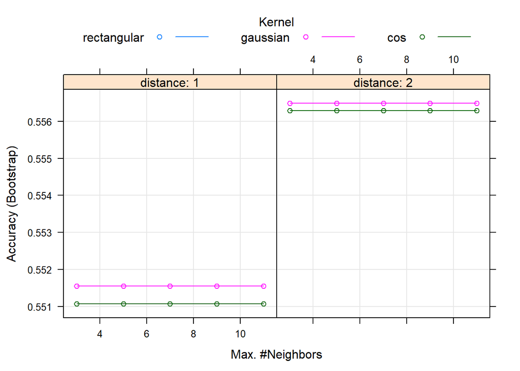

```r
  plot(knn.fit)
```

```r
  knn.fit$bestTune
```

```
##    kmax distance      kernel
## 16    3        2 rectangular
```

So we can see we get the best model for a rectangular kernel with distance 2 which represents euclidean distance and kmax=3.And also we get an accuracy of 59.96%.

## 2) Random forest

```r
  rf.grid<-expand.grid(mtry=1:11)
  rf.fit<-train(quality~.,data=train.red,method="rf",trcontrol=tr.ctrl,tuneGrid=rf.grid,preProcess=c("center","scale"))
  confusionMatrix(predict(rf.fit,test.red),test.red$quality)
```

```
## Confusion Matrix and Statistics
##
##           Reference
## Prediction   3   4   5   6   7   8
##          3   0   0   0   0   0   0
##          4   0   0   0   0   0   0
##          5   3  10 167  38   2   0
##          6   0   5  37 146  37   2
##          7   0   0   0   7  20   2
##          8   0   0   0   0   0   1
##
## Overall Statistics
##
##                Accuracy : 0.7002
##                  95% CI : (0.6569, 0.741)
##     No Information Rate : 0.4277
##     P-Value [Acc > NIR] : < 2.2e-16
##
##                   Kappa : 0.5042
##
##  Mcnemar's Test P-Value : NA
##
## Statistics by Class:
##
##                      Class: 3 Class: 4 Class: 5 Class: 6 Class: 7 Class: 8
## Sensitivity          0.000000  0.00000   0.8186   0.7644  0.33898 0.200000
## Specificity          1.000000  1.00000   0.8059   0.7168  0.97847 1.000000
## Pos Pred Value            NaN      NaN   0.7591   0.6432  0.68966 1.000000
## Neg Pred Value       0.993711  0.96855   0.8560   0.8200  0.91295 0.991597
## Prevalence           0.006289  0.03145   0.4277   0.4004  0.12369 0.010482
## Detection Rate       0.000000  0.00000   0.3501   0.3061  0.04193 0.002096
## Detection Prevalence 0.000000  0.00000   0.4612   0.4759  0.06080 0.002096
## Balanced Accuracy    0.500000  0.50000   0.8122   0.7406  0.65873 0.600000
```

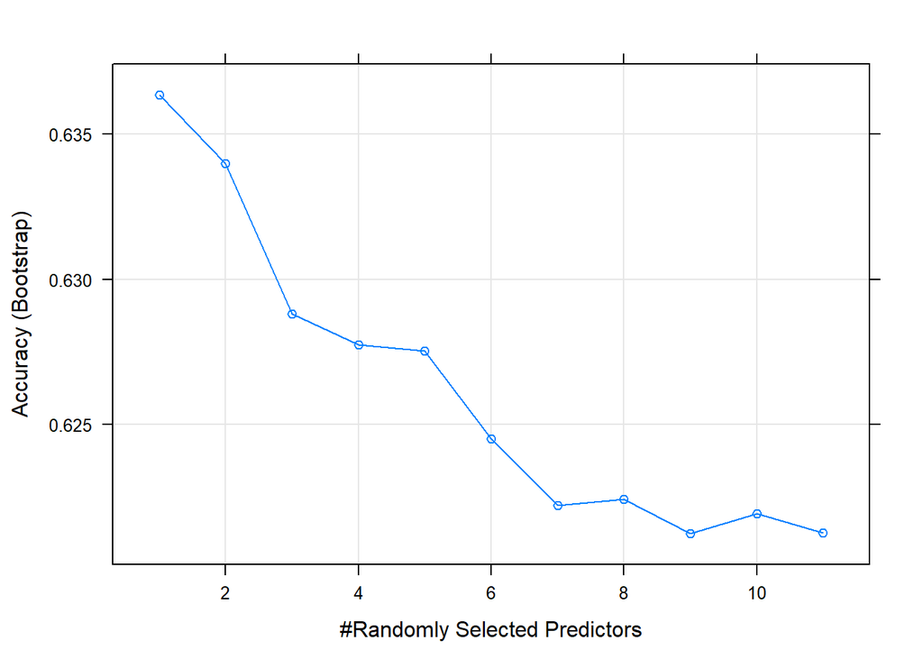

```r
  plot(rf.fit)
```

```r
  rf.fit$bestTune
```

```
##   mtry
## 1    1
```